# Fast and Accurate Modelling of Longitudinal and Repeated Measures Neuroimaging Data

B. Guillaume, X. Hua, P. M. Thompson, L. Waldorp, T. E. Nichols

# The Linear Mixed Effects Model

For individual $i \in \{1, ..., m\}$ with $n_i$ observations:

$$y_i = X_i \beta + Z_i b_i + \epsilon_i$$

- $y_i, \epsilon_i \in \mathbb{R}^{n_i}$
- $\beta \in \mathbb{R}^p$
- $X_i \in \mathbb{R}^{n_i \times p}$
- $b_i \in \mathbb{R}^r$
- $Z_i \in \mathbb{R}^{n_i \times r}$
- $\epsilon_i \sim \mathcal{N}_{n_i} (0, \Sigma_i)$

Can think of it as fitting $m$ linear models, one for each individual

… BUT note that:

- $\beta$ has no subscript $i$—use common $\beta$ across all $m$ individuals
- $b_i$ is different for each individual, but we assume $b_i \sim \mathcal{N}_r(0, D)$
  - also assuming $b_i \perp \epsilon_i$

# The Marginal Model

If we marginalize the random effects:

$$y_i = X_i \beta + \epsilon_i^*$$

Common model for each individual

Variance explained by $b_i$’s absorbed into $\epsilon_i^*$

$\epsilon_i^* \sim \mathcal{N}_{n_i}(0, V_i)$  
$\implies \epsilon^* \sim \mathcal{N}_{\sum_i n_i}(0, V)$  
where $V$ is a block diagonal matrix of $V_i$’s

$V_i = \Sigma_i + Z_i D Z_i$

# The Sandwich Estimator

To estimate fixed effects coefficients:

$$\hat{\beta} =
\bigg(\sum_i^m X_i^\top W_i X_i \bigg)^{-1} \sum_i^m X_i^\top W_i y_i$$

- $W_i$: working covariance matrix
  - $W_i = V_i^{-1}$ for UMVUE

In order to determine “significance” of the slope, we need:

$$\hat{Var}(\hat{\beta}) = \bigg( \sum_i X_i^\top W_i X_i \bigg)^{-1}
\bigg( \sum_i X_i^\top W_i \hat{V}_i W_i X_i \bigg)
\bigg( \sum_i X_i^\top W_i X_i \bigg)^{-1}$$

- $p \times p$ matrix
- this is the sandwich estimator
- $m^{-1} \sum_i^m X_i^\top W_i \hat{V}_i W_i X_i \to m^{-1} \sum_i^m X_i^\top W_i V_i W_i X_i \implies \hat{Var}(\hat{\beta}) \to Var(\hat{\beta})$
  - True even if $W_i$ is misspecified
  - Even if we incorrectly assume GLS or even OLS conditions, this still converges to the correct value
    - But can result in loss of efficiency (requires greater $m$ and $n_i$’s to get closer to true value)
    - This paper uses $W_i = I$
    - Efficiency can be made up for by careful construction of design matrix
- $\hat{V}_i$ typically from crossproduct of residuals $\hat{V}_i = e_i e_i^\top$

# Hypothesis testing

Have both $\hat{\beta}$ and $\hat{Var}(\hat{\beta}) = S$

LME assumptions imply $\hat{\beta}$ is normal

$\implies$ have all the tools for hypothesis testing  
$H_0: c \beta = 0$

$$T = (c \hat{\beta})^\top (c S c^\top)^{-1} (c \hat{\beta}) / q$$

$$T \stackrel{p}{\to} \chi^2_q$$

- $q = 1$ for most cases we’ve dealt with in class
- $q$ is the rank of $c$ when $c$ is a contrast matrix

# Homogeneous Sandwich Estimator

- Instead of separate $V_i$ per subject, group subjects into $n_G$ groups that share $V_i$

To estimate $V_{0g}$, the shared covariance matrix for group $g$:

- $I(g, j, k)$ is the set of subjects in group $g$ with data from both visits $j$ and $k$
- $[\hat{V}_{0g}]_{jj} = m_{gjj}^{-1} \sum_{i \in I(g, j, j)} e_{ij}^2$
- $[\hat{V}_{0g}]_{jk} = \hat{\rho}_{0gjk} \sqrt{[\hat{V}_{0g}]_{jj} [\hat{V}_{0g}]_{kk}}$
- $\hat{\rho}_{0gjk} = \frac{\sum_{i \in I(g, j, k)} e_{ij} e_{ik}} {\sqrt{(\sum_{i \in I(g, j, k)} e_{ij}^2)(\sum_{i \in I(g, j, k)} e_{ik}^2)}}$
- $V_{0g}$ not guarnateed to be positive semidefinite when data are missing— use spectral decomposition to truncate negative eigenvalues

# Small Sample Adjustments

1. Standard heterogeneous maximum likelihood sandwich estimator is biased
   - Underestimation of variance
   - Inflated false positive rates
2. Using a point estimator for $Var(\hat{\beta})$ to estimate $T$ results in heavier tails (analogous to $z$-test vs $t$-test)

Corrections

1. Three approaches in the literature
   1. Multiply the residuals by a correction factor $\sqrt{n / (n - p)}$
   2. Use adjusted residuals $e_{ik} / \sqrt{1 - h_{ik}}$
      - $H = X (X^\top X)^{-1} X^\top$
      - Index $ik$ refers to individual $i$ and session $k$
   3. Use adjusted residuals $e_{ik} / (1 - h_{ik})$
2. Instead of using $T \stackrel{p}{\to} \chi^2_q$ which only really works when $S = Var(\hat{\beta})$, use $\frac{\nu - q + 1}{\nu q} (c \hat{\beta})^\top (c S c^\top)^{-1} (c \hat{\beta}) \stackrel{p}{\to} F(q, \nu - q + 1)$
   - When $q = 1$ (i.e., $c$ is a contrast vector), we can take the square root and get a $t$ distribution with $\nu$ degress of freedom
   - Need to estimate $\nu$

# Analysis

## Simulations

Regressors considered:

- Intercept term
- $\overline{Age}_i - \overline{Age}$
- $Age - \overline{Age}_i$
- Interaction term
- Visit

Group cvariance structure:

- $Var(Y_{ik}) = \alpha_g (1 + \gamma t_k)$
- $Corr(Y_{ij}, Y_{ik}) = \rho (1 = \psi |t_j - t_k|)$
- Different correlation structures

## Real data

Alzheimer’s Disease Neuroimaging Initiative (ANI)

## Estimating $\hat{Var}(\hat{\beta})$:

- Homogeneous (assuming group structure) vs heterogeneous (different $V_i$ per subject)
- Four methods:
  - MLE
  - $\sqrt{n / (n-p)}$ adjustment
  - $e_{ik} / \sqrt{1 - h_{ik}}$ adjustment
  - $e_{ik} / (1 - h_{ik})$ adjustment
- Various estimation methods for $\nu$

# Simulation Results

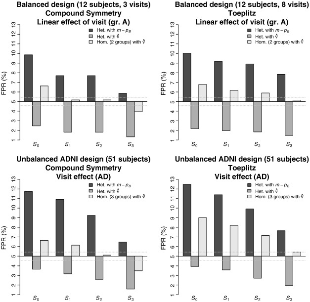

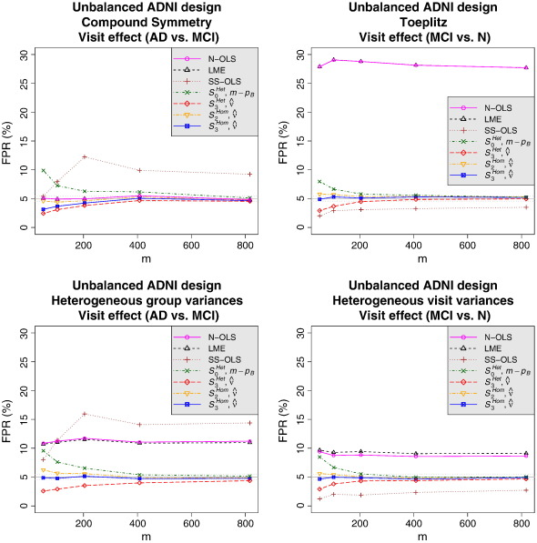

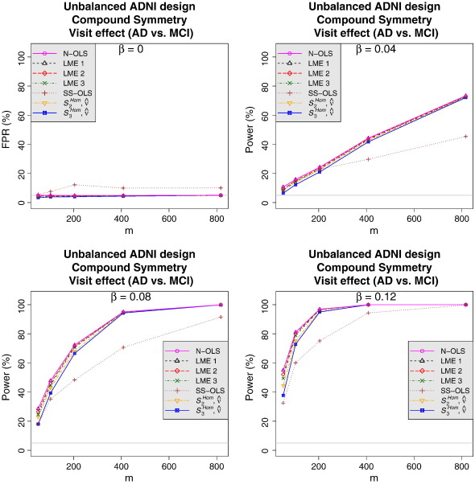

# Real Data Results: Comparison of OLS vs SwE

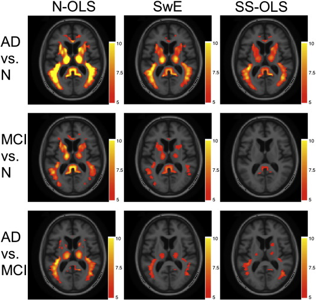

- Consistent with simulation results
  - N-OLS has more voxels testing as positive
  - SS-OLS has fewer voxels testing as positive
- SwE assumes group covariance structure and uses the $e_{ij} = e_{ij} / (1 - h_{ij})$ adjustment

# Real Data Analysis: Deep-Dive into Particular Voxels

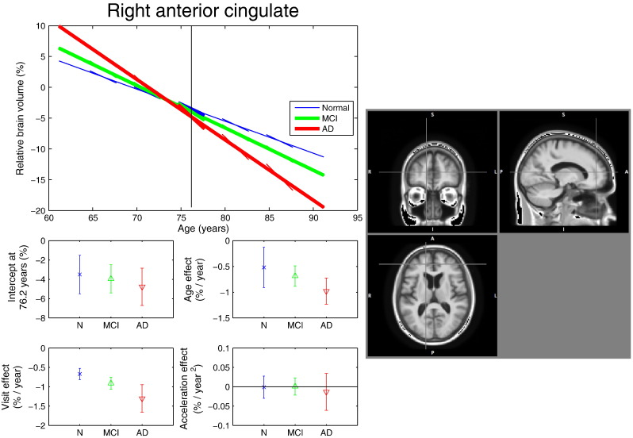

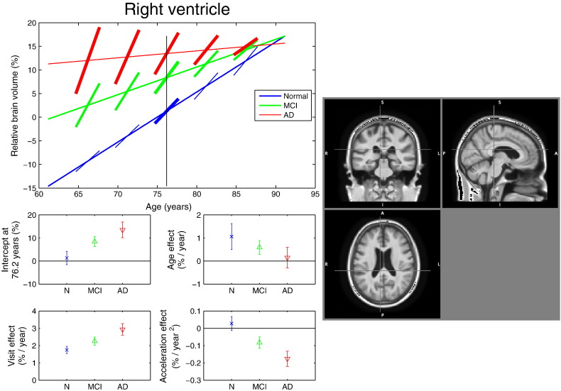

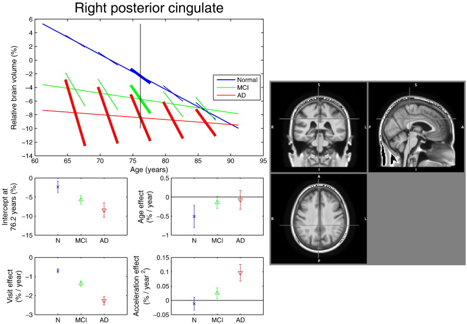